# lab5

Zeyuan Fang

8/28/2021

ID: 556588804  
UPI:zfan253

## Description of the Data

The data source for this lab is a set of 31 CSV files containing 15-minute vehicle counts from January 2013 (/course/NZTA/20130101_20130331_TMSTrafficQuarterHour.csv) to September 2020 (/course/NZTA/20200701_20200930_TMSTrafficQuarterHour.csv).

### Task1

```r
path= "/course/NZTA"
files <- list.files(path,pattern = "^[0-9]",full.names = T)
head(files)
```

```
## [1] "/course/NZTA/20130101_20130331_TMSTrafficQuarterHour.csv"
## [2] "/course/NZTA/20130401_20130630_TMSTrafficQuarterHour.csv"
## [3] "/course/NZTA/20130701_20130930_TMSTrafficQuarterHour.csv"
## [4] "/course/NZTA/20131001_20131231_TMSTrafficQuarterHour.csv"
## [5] "/course/NZTA/20140101_20140331_TMSTrafficQuarterHour.csv"
## [6] "/course/NZTA/20140401_20140630_TMSTrafficQuarterHour.csv"
```

### Task2

```r
readFile <- function(filename) {
    countsDT <- fread(filename)
    countsDT[, day := substr(startDatetime, 1, 11)][, .(count = sum(count)), .(day, siteRef, class)]
}
```

```r
system.time(trafficSeries <- do.call(rbind,lapply(files[1:5],readFile)))
```

```
##    user  system elapsed
## 162.804   3.194  34.179
```

```r
dim(trafficSeries)
```

```
## [1] 365635      4
```

```r
head(trafficSeries)
```

```
##            day  siteRef class   count
## 1: 21-FEB-2013 01S00376     H  1926.0
## 2: 23-FEB-2013 01S00376     H   901.5
## 3: 24-FEB-2013 01S00376     L 12360.5
## 4: 25-FEB-2013 01S00376     L  9858.5
## 5: 25-FEB-2013 01S00376     H  1729.5
## 6: 26-FEB-2013 01S00376     L  9399.0
```

### Task3

use mclapply and measure the time.

```r
system.time(mctrafficSeries <- do.call(rbind,mclapply(files[1:5],readFile,mc.cores = 5)))
```

```
##    user  system elapsed
##  21.218   1.824   7.188
```

It's much faster.

### Task4

```r
dim(mctrafficSeries)
```

```
## [1] 365635      4
```

```r
head(mctrafficSeries)
```

```
##            day  siteRef class   count
## 1: 21-FEB-2013 01S00376     H  1926.0
## 2: 23-FEB-2013 01S00376     H   901.5
## 3: 24-FEB-2013 01S00376     L 12360.5
## 4: 25-FEB-2013 01S00376     L  9858.5
## 5: 25-FEB-2013 01S00376     H  1729.5
## 6: 26-FEB-2013 01S00376     L  9399.0
```

Produce same result

### Task5

use parLapply and measure the time.

```r
system.time({
  cl <- makeCluster(5)
  clusterExport(cl, "files")
  clusterExport(cl,"readFile")
  clusterExport(cl,"fread")
  cltrafficSeries <- do.call(rbind,parLapply(cl,files[1:5],readFile))
  stopCluster(cl)
})
```

```
##    user  system elapsed
##   0.205   0.008  20.286
```

Faster than lapply, but slower than mclapply()

### Task6

Since we have overall 31 big files, and the number of cpu is more than 31. We can use 31 cores for this task.

```r
system.time(
traffic <- do.call(rbind,mclapply(files,readFile,mc.cores = 31))
)
```

```
##    user  system elapsed
## 206.885  17.974  13.174
```

```r
gc()
```

```
##            used  (Mb) gc trigger  (Mb)  max used   (Mb)
## Ncells  1831977  97.9    2857557 152.7   2857557  152.7
## Vcells 47738158 364.3  112198272 856.1 146340172 1116.5
```

```r
traffic <- traffic[, .(day, siteRef, class, scount = sqrt(count))]
traffic <- traffic[!is.na(scount), ]
```

```r
dim(traffic)
```

```
## [1] 2710949       4
```

```r
head(traffic)
```

```
##            day  siteRef class    scount
## 1: 21-FEB-2013 01S00376     H  43.88622
## 2: 23-FEB-2013 01S00376     H  30.02499
## 3: 24-FEB-2013 01S00376     L 111.17779
## 4: 25-FEB-2013 01S00376     L  99.28998
## 5: 25-FEB-2013 01S00376     H  41.58726
## 6: 26-FEB-2013 01S00376     L  96.94844
```

The peak memory usage is creating traffic object since it comes from 31 files rather than 5.

### Task7

The size of the model matrix for scount~class model is $2710949\times2$, with Intercept column 1 and classL colunmn 0 or 1, and that for scount~class+siteRef is $2710949\times(\#Unique(siteRef)+2)$, where for every column of siteRef, it is a hot-vector and there is only one 1 and rest are all 0, hence we should use a sparse matrix.

```r
 dim(model.Matrix(scount ~ class+siteRef,
                          data=traffic, sparse=TRUE))
```

```
## [1] 2710949    1703
```

### Task8

```r
index <- sample(rep(1:10, length.out=nrow(traffic)))
sites <- levels(factor(traffic$siteRef))
RMSE <- function(obs, pred) {
    sqrt(mean((obs - pred[,1])^2,na.rm = T))
}
fitLM <- function(i) {
    train <- traffic[index != i, ]
    train[, siteRef := factor(siteRef, levels=sites)]
    test <- traffic[index == i, ]
    test[, siteRef := factor(siteRef, levels=sites)]
    fit1 <- glm4(scount ~ class, data=train, sparse=TRUE)
    coef1 <- coef(fit1)
    rm(fit1)
    fit2 <- glm4(scount ~ class + siteRef, data=train, sparse=TRUE)
    coef2 <- coef(fit2)
    rm(fit2)
    pred1 <- model.Matrix(scount ~ class,
                          data=test, sparse=TRUE) %*%
                 coef1
    pred2 <- model.Matrix(scount ~ class + siteRef,
                          data=test, sparse=TRUE) %*%
                 coef2
    obs <- test$scount
    #pred1
    c( RMSE(obs,pred1), RMSE(obs,pred2))
}
```

```r
system.time({
  rmse <- do.call(rbind,lapply(1:10,function(i) fitLM(i)))
})
```

```
##    user  system elapsed
##  83.983   1.638  81.848
```

The average RMSE for both models are:

```r
(RMSE_m1 <-colMeans(rmse)[1])
```

```
## [1] 43.99775
```

```r
(RMSE_m2 <- colMeans(rmse)[2])
```

```
## [1] 22.18974
```

### Task9

```r
system.time({
  rmse <- do.call(rbind,mclapply(1:10,function(i) fitLM(i),mc.cores = 10))
})
```

```
##    user  system elapsed
##  76.615   7.976  10.388
```

```r
(RMSE_m1 <-colMeans(rmse)[1])
```

```
## [1] 43.99775
```

```r
(RMSE_m2 <- colMeans(rmse)[2])
```

```
## [1] 22.18974
```

```r
gc()
```

```
##            used  (Mb) gc trigger   (Mb)  max used   (Mb)
## Ncells  1859465  99.4    6413704  342.6   4453608  237.9
## Vcells 50140909 382.6  157030017 1198.1 196272021 1497.5
```

1.Unsurprisingly, mcallpy() is much faster than lapply().

2.Comparing with gc() with task6, we only used around 20Mb(382.6Mb -364.3Mb) memory to save the result for task8(or task9). This is because lm.fit object is memory comsuming and we did gabbage collection by rm(fit) in every iteration.

### Task10

```r
fit <- glm4(scount ~ class + siteRef, data=traffic, sparse=TRUE)
coefs <- coef(fit)
rm(fit)
pred <- model.Matrix(scount ~ class+siteRef,
                          data=traffic, sparse=TRUE) %*% coefs
#pred <- pred[,1]
#obs <- traffic$scount
```

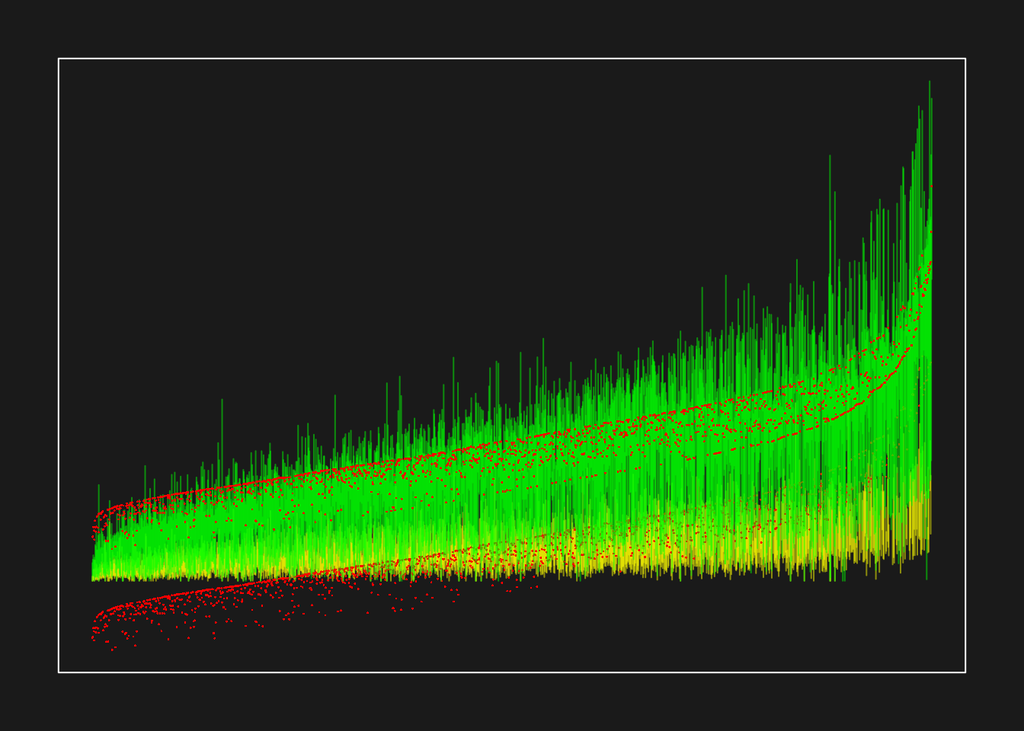

```r
traffic$pred <- pred[,1]
traffic$site <- reorder(as.factor(traffic$siteRef), traffic$scount)
trafficClass <- split(traffic, traffic$class)
plotClass <- function(x, col) {
   sites <- split(x, x$site, drop=TRUE)
   siteMin <- sapply(sites, function(y) min(y$scount))
   siteMax <- sapply(sites, function(y) max(y$scount))
   pred <- sapply(sites, function(y) y$pred[1])
   s <- as.numeric(factor(sapply(sites, function(y) y$siteRef[1]),
                          levels=levels(x$site)))
   segments(s, siteMin, s, siteMax, col=col)
   points(s, pred, pch=16, cex=.2, col="red")
}
bg <- "grey10"
par(bg=bg, mar=rep(2, 4))
plot(traffic$site, traffic$scount, border=NA, ann=FALSE, axes=FALSE,
     ylim=range(traffic$scount, traffic$pred))
usr <- par("usr")
rect(usr[1], usr[3], usr[2], usr[4], col=bg)
box(col="white")
plotClass(trafficClass[[1]], adjustcolor("yellow", alpha=.5))
plotClass(trafficClass[[2]], adjustcolor("green", alpha=.5))
```

Plot of all of the data with the predictions from class + siteRef model

## Summary

In this lab, we focus on parallel computing. To test what’s the fastest way for loading data, first we try on five of 31 files. We find using “forker” workers is faster than using “cluster” of workers, which is faster than plain lapply(). Then we read all 31 files into a R data table using “forker” wokrers(mclapply), and transform it into our desiring table. Next, we want to build models based on the data table. We notice that for the model size is proportional to the data size. Hence a model with more varialbe (or many levels variable) is memory-consuming. What we do is only keep the weights of the model(coefficients), and use Matrix Multiplication with sparse matrix to compute the prediction value. And for the modeling task, we also test the time difference between a single thread version(lapply) and a “forked” workers version(mclapply). Finally, we made a visulation and produce a plot of all of the data with the predictions from class + siteRef model .